# hw5

Simon Lee

2022-11-18

```r
library(tidymodels)
library(tidyverse)
library(ggplot2)
library(corrr)
library(corrplot)
library(klaR)
library(glmnet)
library(MASS)
library(discrim)
library(poissonreg)
tidymodels_prefer()
```

```r
poke_data <- read_csv("data/pokemon.csv")
```

# q1

```r
library(janitor)
poke_data <- poke_data %>% clean_names()
poke_data %>% head()
```

```
## # A tibble: 6 × 13
##   number name       type_1 type_2 total    hp attack defense sp_atk sp_def speed
##    <dbl> <chr>      <chr>  <chr>  <dbl> <dbl>  <dbl>   <dbl>  <dbl>  <dbl> <dbl>
## 1      1 Bulbasaur  Grass  Poison   318    45     49      49     65     65    45
## 2      2 Ivysaur    Grass  Poison   405    60     62      63     80     80    60
## 3      3 Venusaur   Grass  Poison   525    80     82      83    100    100    80
## 4      3 VenusaurM… Grass  Poison   625    80    100     123    122    120    80
## 5      4 Charmander Fire   <NA>     309    39     52      43     60     50    65
## 6      5 Charmeleon Fire   <NA>     405    58     64      58     80     65    80
## # … with 2 more variables: generation <dbl>, legendary <lgl>
```

clean_names() changes variable names with special characters, spaces, and anything else that is not conventional naming. And replaces it with more conventional naming characters. clean_names() was used here and the variable sp.atk and sp.def was changed to sp_atk and sp_def

# q2

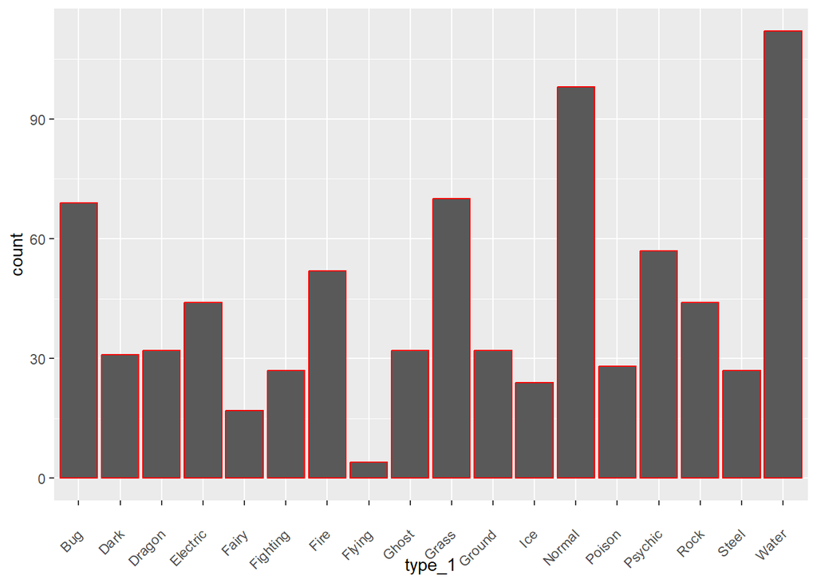

```r
type_bar <- ggplot(poke_data, aes(x = type_1)) + geom_bar(color = "red") + theme(axis.text.x = element_text(angle = 45, vjust = 0.5, hjust=1))
type_bar
```

There are 18 types of pokemon in the data. From the bar chart, there are few fairy and flying type pokemon.

```r
fpoke_data <- poke_data %>% filter((type_1 == "Bug" | type_1 == "Fire" | type_1 == "Grass" | type_1 == "Normal" |
                           type_1 == "Water" | type_1 == "Psychic"))
fpoke_data$type_1 <- as.factor(fpoke_data$type_1)
fpoke_data$legendary <- as.factor(fpoke_data$legendary)
fpoke_data$generation <- as.factor(fpoke_data$generation)
```

# q3

```r
set.seed(115)
poke_split <- initial_split(fpoke_data, prop = 0.8, strata = type_1)
poke_train <- training(poke_split)
poke_test <- testing(poke_split)

poke_fold <- vfold_cv(data = poke_train, v=5, strata = type_1)
poke_fold
```

```
## #  5-fold cross-validation using stratification
## # A tibble: 5 × 2
##   splits           id
##   <list>           <chr>
## 1 <split [289/75]> Fold1
## 2 <split [291/73]> Fold2
## 3 <split [291/73]> Fold3
## 4 <split [292/72]> Fold4
## 5 <split [293/71]> Fold5
```

We stratify the folds as well as the testing data in order for the models we train them on to be representative of the true distribution. Otherwise the folds won’t be accounting for the distribution of type_1 and the model wouldn’t work

# q4

```r
poke_recipe <- recipe(type_1 ~ legendary + generation + sp_atk + attack + speed + defense + hp + sp_def, data= poke_train) %>%
  step_dummy(legendary) %>%
  step_dummy(generation) %>%
  step_normalize(all_predictors())
```

# q5

```r
poke_spec <- multinom_reg(penalty = tune(), mixture = tune()) %>%
  set_mode("classification") %>%
  set_engine("glmnet")

poke_wf <- workflow() %>%
  add_recipe(poke_recipe) %>%
  add_model(poke_spec)

penalty_grid <- grid_regular(penalty(range = c(-5,5)),
                             mixture(range = c(0,1)),
                             levels = 10)
```

Since we are tuning mixture and penalty with 10 levels each, there will be 100 models in total

# q6

```r
tune_res <- tune_grid(poke_wf, resamples = poke_fold, grid = penalty_grid)
tune_res
```

```
## # Tuning results
## # 5-fold cross-validation using stratification
## # A tibble: 5 × 4
##   splits           id    .metrics           .notes
##   <list>           <chr> <list>             <list>
## 1 <split [289/75]> Fold1 <tibble [200 × 6]> <tibble [0 × 3]>
## 2 <split [291/73]> Fold2 <tibble [200 × 6]> <tibble [0 × 3]>
## 3 <split [291/73]> Fold3 <tibble [200 × 6]> <tibble [0 × 3]>
## 4 <split [292/72]> Fold4 <tibble [200 × 6]> <tibble [0 × 3]>
## 5 <split [293/71]> Fold5 <tibble [200 × 6]> <tibble [0 × 3]>
```

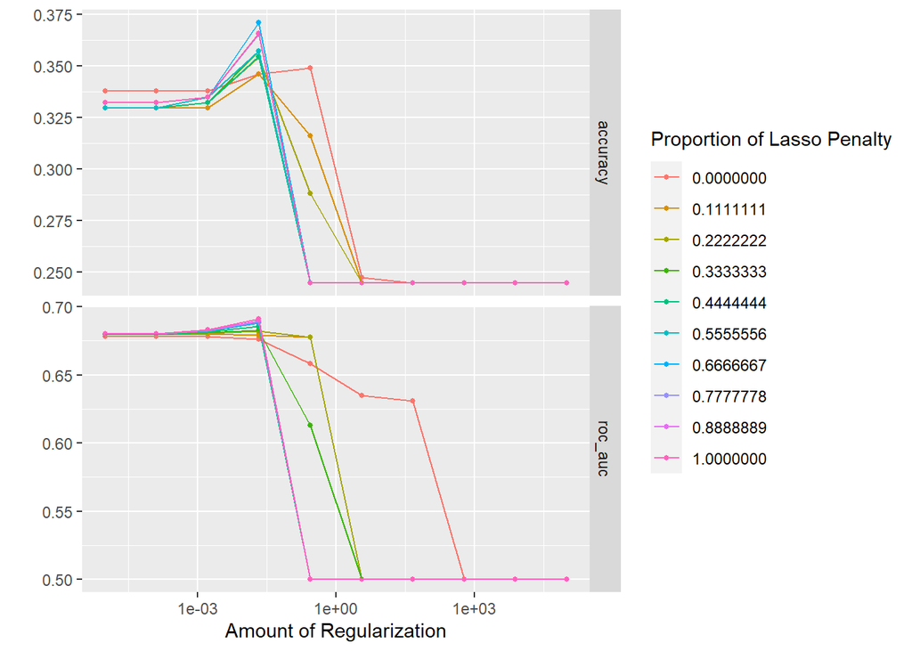

```r
autoplot(tune_res)
```

```r
collect_metrics(tune_res)
```

```
## # A tibble: 200 × 8
##     penalty mixture .metric  .estimator  mean     n std_err .config
##       <dbl>   <dbl> <chr>    <chr>      <dbl> <int>   <dbl> <chr>
##  1 0.00001        0 accuracy multiclass 0.338     5 0.0243  Preprocessor1_Model…
##  2 0.00001        0 roc_auc  hand_till  0.678     5 0.0175  Preprocessor1_Model…
##  3 0.000129       0 accuracy multiclass 0.338     5 0.0243  Preprocessor1_Model…
##  4 0.000129       0 roc_auc  hand_till  0.678     5 0.0175  Preprocessor1_Model…
##  5 0.00167        0 accuracy multiclass 0.338     5 0.0243  Preprocessor1_Model…
##  6 0.00167        0 roc_auc  hand_till  0.678     5 0.0175  Preprocessor1_Model…
##  7 0.0215         0 accuracy multiclass 0.346     5 0.0244  Preprocessor1_Model…
##  8 0.0215         0 roc_auc  hand_till  0.676     5 0.0164  Preprocessor1_Model…
##  9 0.278          0 accuracy multiclass 0.349     5 0.00884 Preprocessor1_Model…
## 10 0.278          0 roc_auc  hand_till  0.658     5 0.0105  Preprocessor1_Model…
## # … with 190 more rows
```

Both roc_auc and accuracy starts off high and drops off around the same place before 1e+00. The lasso penalty values seem similar in results in providing results in roc_auc and accuracy.

# q7

```r
best_penalty <- select_best(tune_res, metric = "roc_auc")
poke_final <- finalize_workflow(poke_wf, best_penalty)
poke_final_fit <- fit(poke_final, data = poke_train)
```

```r
final_acc <- augment(poke_final_fit, new_data = poke_test) %>%
  accuracy(truth = type_1, estimate = .pred_class)
final_acc
```

```
## # A tibble: 1 × 3
##   .metric  .estimator .estimate
##   <chr>    <chr>          <dbl>
## 1 accuracy multiclass     0.319
```

# q8

```r
total_roc_auc <- augment(poke_final_fit, new_data = poke_test) %>%
  roc_auc(truth = type_1, estimate = c(.pred_Bug, .pred_Fire, .pred_Grass, .pred_Normal, .pred_Psychic, .pred_Water))
total_roc_auc
```

```
## # A tibble: 1 × 3
##   .metric .estimator .estimate
##   <chr>   <chr>          <dbl>
## 1 roc_auc hand_till      0.667
```

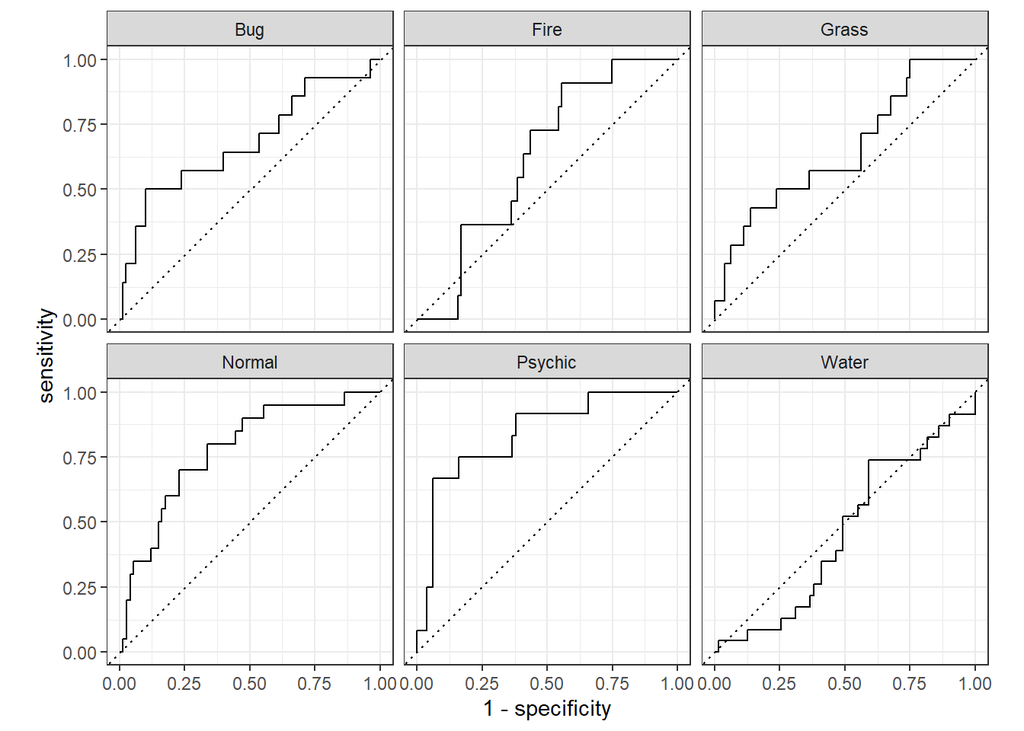

```r
roc_curves <- augment(poke_final_fit, new_data = poke_test) %>%
  roc_curve(truth = type_1, estimate = c(.pred_Bug, .pred_Fire, .pred_Grass, .pred_Normal, .pred_Psychic, .pred_Water)) %>%
  autoplot()
roc_curves
```

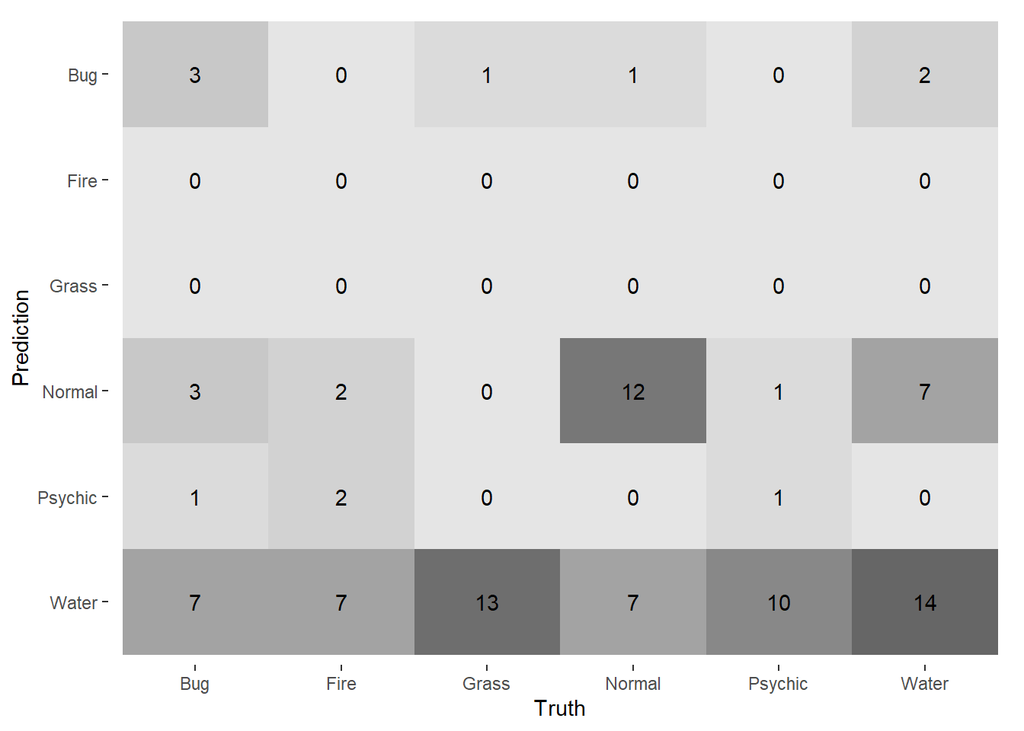

```r
final_model_conf <- augment(poke_final_fit, new_data = poke_test) %>%
  conf_mat(truth = type_1, estimate = .pred_class) %>%
  autoplot(type = "heatmap")
final_model_conf
```

The model didn’t perform that well with an accuracy of only around 32 percent and a roc_auc of 66 percent. The model seemed to be the worst at predicting grass and fire types. It was also bad at predicting bug and psychic types. It was best at predicting water and normal types. This might be due to the sheer amount of water and normal type Pokemon in our data and that leading to more positive truths in the confusion matrix.